# F Application Report

Greg Cooke

2023-11-25

In this report I will look to highlight the firms that should be focused on by our supervisors using key metrics that I will explain throughout the report. I will keep all my code in the report for audit and reusability purposes as conclusions may change as new data arrives. I will focus this piece on the three main characteristics stated: Firm Size, Changing Business Profile and Outliers.

## Data Loading and Wrangling

I have used a combination of *openxlsx* and *tidyverse* packages to render the xlsx into a R-readable output. Below I have produced a summary of all the variables.

|  | firm | year | value_type | eof_for_scr_m | equity_m | gwp_m | gross_bel_m | gross_claims_incurred_m | gross_combined_ratio | gross_expense_ratio | nwp_m | net_bel_m | net_combined_ratio | net_expense_ratio | pure_gross_claims_ratio | pure_net_claims_ratio | scr_m | scr_coverage_ratio | total_assets_m | total_liabilities_m |
| --- | --- | --- | --- | --- | --- | --- | --- | --- | --- | --- | --- | --- | --- | --- | --- | --- | --- | --- | --- | --- |
|  | Length:9120 | Length:9120 | Length:9120 | Min. : -162.25 | Min. : -123.610 | Min. : -19.78 | Min. : -167.82 | Min. :-189.936 | Min. : -14064 | Min. :-16112.4 | Min. :-17754.10 | Min. : -182.382 | Min. :-5468706 | Min. :-4495420 | Min. :-24817.8 | Min. :-33721.0 | Min. : 0.000 | Min. : -3 | Min. : -207.4 | Min. : -1487.1 |
|  | Class :character | Class :character | Class :character | 1st Qu.: 5.98 | 1st Qu.: 5.798 | 1st Qu.: 0.00 | 1st Qu.: 0.00 | 1st Qu.: 0.000 | 1st Qu.: 0 | 1st Qu.: 0.0 | 1st Qu.: 0.00 | 1st Qu.: 0.000 | 1st Qu.: 0 | 1st Qu.: 0 | 1st Qu.: 0.0 | 1st Qu.: 0.0 | 1st Qu.: 1.794 | 1st Qu.: 1 | 1st Qu.: 14.4 | 1st Qu.: 3.8 |
|  | Mode :character | Mode :character | Mode :character | Median : 32.09 | Median : 34.276 | Median : 15.47 | Median : 10.48 | Median : 3.392 | Median : 0 | Median : 0.1 | Median : 7.95 | Median : 4.502 | Median : 0 | Median : 0 | Median : 0.2 | Median : 0.1 | Median : 14.533 | Median : 2 | Median : 113.0 | Median : 63.0 |
|  | NA | NA | NA | Mean : 455.68 | Mean : 480.865 | Mean : 853.94 | Mean : 259.07 | Mean : 116.696 | Mean : 1859 | Mean : 273.7 | Mean : 689.12 | Mean : 164.284 | Mean : 172 | Mean : 1370 | Mean : 463.0 | Mean : 388.1 | Mean : 308.437 | Mean : 1301158 | Mean : 6333.0 | Mean : 6363.4 |
|  | NA | NA | NA | 3rd Qu.: 165.65 | 3rd Qu.: 176.937 | 3rd Qu.: 198.96 | 3rd Qu.: 159.34 | 3rd Qu.: 79.463 | 3rd Qu.: 1 | 3rd Qu.: 0.3 | 3rd Qu.: 125.95 | 3rd Qu.: 93.771 | 3rd Qu.: 1 | 3rd Qu.: 0 | 3rd Qu.: 0.5 | 3rd Qu.: 0.5 | 3rd Qu.: 95.191 | 3rd Qu.: 3 | 3rd Qu.: 955.4 | 3rd Qu.: 655.7 |
|  | NA | NA | NA | Max. :41636.30 | Max. :26705.042 | Max. :74078.64 | Max. :19292.07 | Max. :6844.014 | Max. :3978266 | Max. :575064.8 | Max. : 75526.67 | Max. :11351.609 | Max. : 2445529 | Max. : 2691212 | Max. :985011.3 | Max. :828809.4 | Max. :22788.359 | Max. :999302877 | Max. :553549.9 | Max. :494498.5 |
|  | NA | NA | NA | NA’s :2620 | NA’s :2620 | NA’s :2620 | NA | NA | NA | NA | NA’s :2620 | NA | NA | NA | NA | NA | NA’s :2620 | NA’s :2620 | NA’s :2620 | NA’s :2620 |

From this summary we can see each of the columns are in the correct data type and there is significant variance across the numeric variables. The dataset looks like this now:

| firm | year | value_type | eof_for_scr_m | equity_m | gwp_m | gross_bel_m | gross_claims_incurred_m | gross_combined_ratio | gross_expense_ratio | nwp_m | net_bel_m | net_combined_ratio | net_expense_ratio | pure_gross_claims_ratio | pure_net_claims_ratio | scr_m | scr_coverage_ratio | total_assets_m | total_liabilities_m |
| --- | --- | --- | --- | --- | --- | --- | --- | --- | --- | --- | --- | --- | --- | --- | --- | --- | --- | --- | --- |
| Firm 1 | 2016 | mean_value | 484.0712 | 249.6647 | 9.353606 | 0.1177988 | 0.0011030 | 0.1350101 | 15.45025 | -3550.820 | 1.978919 | 14.25977 | 8.202612 | 3.506938 | 3.436862 | 404.2644 | 11177400.6440186 | 12737.29 | 8034.337 |
| Firm 1 | 2016 | median_value | 0.0000 | 0.0000 | 0.000000 | 0.0000000 | 0.0000000 | 0.0000000 | 0.00000 | 0.000 | 0.000000 | 0.00000 | 0.000000 | 0.000000 | 0.000000 | 0.0000 | 0.0000000 | 0.00 | 0.000 |
| Firm 1 | 2016 | sd_value | 1080.2952 | 555.8116 | 20.915299 | 0.2634062 | 0.0024665 | 0.3018918 | 34.54781 | 7939.875 | 4.424999 | 31.88581 | 18.341598 | 7.841752 | 7.685056 | 903.9626 | 24993427.5609242 | 28476.09 | 17965.323 |
| Firm 1 | 2016 | time_series_value | 2416.5598 | 1243.9250 | 46.768030 | 0.0000000 | 0.0000000 | 0.0000000 | 0.00000 | -17754.100 | 0.000000 | 0.00000 | 0.000000 | 0.000000 | 0.000000 | 2021.3219 | 0.1625197 | 63676.87 | 40171.683 |
| Firm 1 | 2017 | mean_value | 484.0712 | 249.6647 | 9.353606 | 0.1177988 | 0.0011030 | 0.1350101 | 15.45025 | -3550.820 | 1.978919 | 14.25977 | 8.202612 | 3.506938 | 3.436862 | 404.2644 | 11177400.6440186 | 12737.29 | 8034.337 |

I have set up the datatable so that only *value_type* *time_series_value* varies over time, all the other variables in this column stay consistent. This makes it straightforward to wrangle to find the top/bottom n firms or most/least varying firms by variable as you will see in my visualisation code.

## Caveats

```r
pull_unique_firms = function(wb, sheet_n){

  openxlsx::readWorkbook(
      xlsxFile = wb,
      sheet = openxlsx::sheets(wb)[sheet_n])['X1'] %>%
    dplyr::pull()

}

firms_sheet1_vec = pull_unique_firms(wb, 1)
firms_sheet2_vec = pull_unique_firms(wb, 2)

length(setdiff(firms_sheet2_vec, firms_sheet1_vec))
```

[output not shown]

There are some caveats which will be worth considering with my data-centric approach to resource allocation, these are:

- Data Quality, I can perform some degree of data cleaning and provide a high level of confidence in data quality however this is not perfect.
- Missing data, we see that 131 more firms (Firm 326 to Firm 456 inclusive) report in the *Underwriting* sheet than in the *General* sheet of the XLSX.

## Correlation Plot

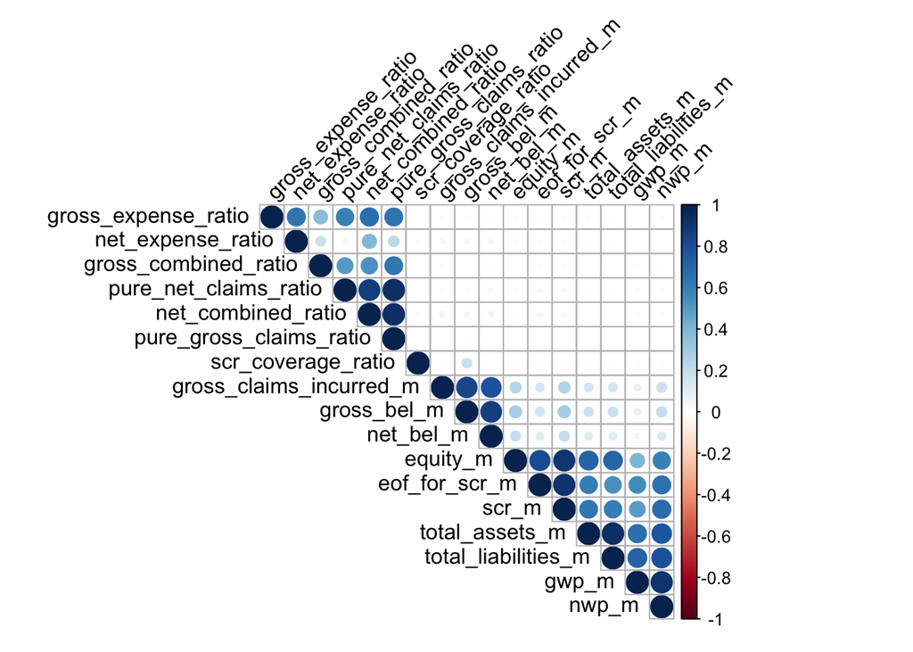

## Firm Size

To consider firm size I will look at:

- *Total Assets*, as assets represent the resources these firms own to generate revenue from.
- *Net Written Premium* this is a better indicator than Gross in my opinion as it considers income post reinsurance costs giving a better picture of profit.
- *Equity*, this represents the amount of money returned to shareholders if the insurer liquidates. This is important as it shows a picture of financial health and stability.

As we want to consider both magnitude and consistency of the variables, I will use the median score to select the highest rated firms and will plot them against the rest.

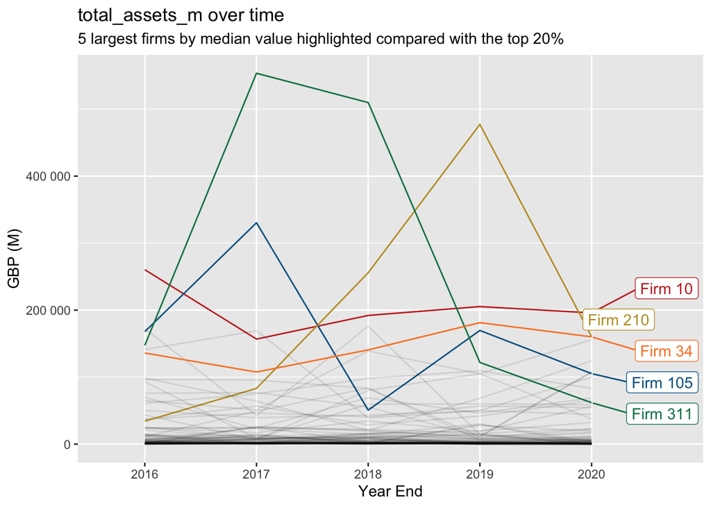

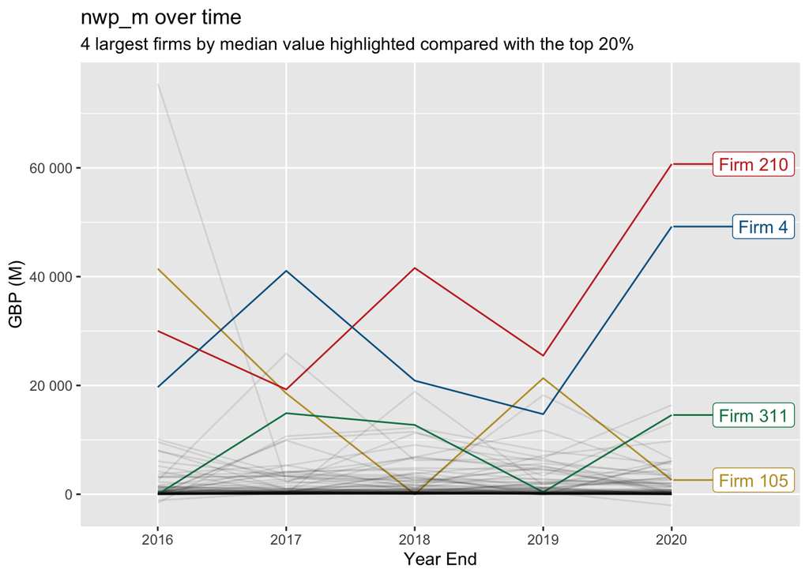

Only Firms 210 and 4 are considerably larger than the rest of the top 20% of firms (for this variable).

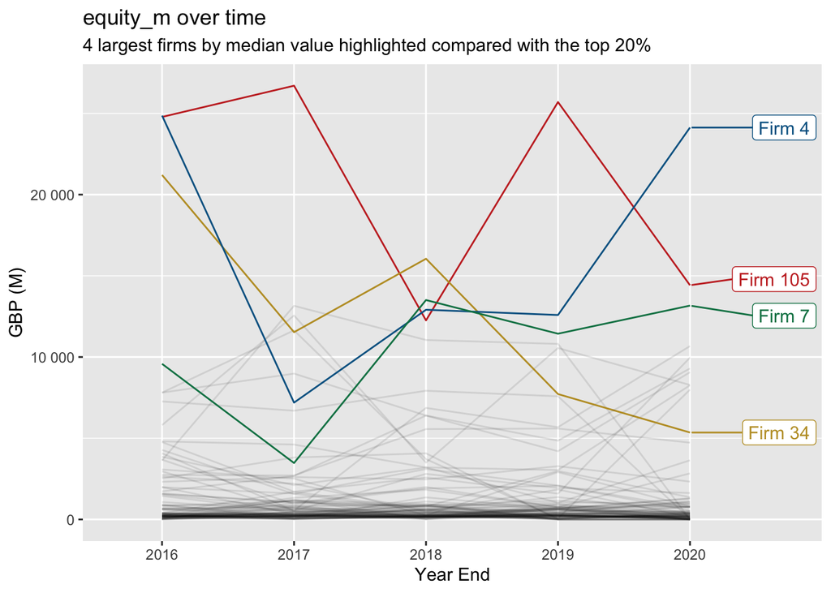

Firm 4 has appears twice now, firstly for having a significantly larger Net Written Premium and now for Equity. This suggests to us that it is a largely profitable insurance firm with a large equity holding meaning it is in a very healthy financial position. I would suggest this firm is definitely an important player in the market and one to monitor.

| firm | size_score | nwp_m_abs_sd_normalised | net_bel_m_abs_sd_normalised | pure_gross_claims_ratio_abs_sd_normalised |
| --- | --- | --- | --- | --- |
| Firm 210 | 29.276608 | 87.153007 | 0.6719286 | 0.0048892 |
| Firm 105 | 20.448670 | 51.795731 | 9.5449170 | 0.0053618 |
| Firm 4 | 19.790848 | 59.012878 | 0.3564204 | 0.0032472 |
| Firm 311 | 11.391854 | 33.933678 | 0.2394160 | 0.0024683 |
| Firm 26 | 10.151985 | 29.369312 | 1.0823845 | 0.0042572 |
| Firm 199 | 8.642304 | 25.674708 | 0.2488247 | 0.0033785 |
| Firm 151 | 6.559077 | 19.274517 | 0.4007712 | 0.0019427 |
| Firm 25 | 5.705377 | 16.702546 | 0.4107381 | 0.0028466 |
| Firm 73 | 5.326167 | 15.714369 | 0.2590468 | 0.0050841 |
| Firm 52 | 5.125987 | 1.249713 | 14.1235304 | 0.0047166 |

I have created a table here that provides a potential list of the top 10 firms **using only firms that reported on the general template also**. I have calculated this by taking the *mean normalised absolute standard deviation of the median value* for each firm on specific metrics. To explain this, I first take the median, because mean is more affected by outliers, value of each metric for each firm and then find the absolute standard deviation against the metric. This allows me to find the firms that are, on average, far above the population for each metric. As the distributions vary for each of the metrics I then normalise each of this scores so that when I take the mean there is no weighting bias. I chose the variable *Net Weighted Premium*, *Net BEL (inc. TPs as a whole, pre-TMTP)* and *Pure Gross Claims Ratio* because as you can see from my correlation matrix above, these three variables explain a lot of the variance of the entire dataset and I felt they were therefore wide ranging and mutually exclusive enough to consider all aspects of the business. It is worth noting as you can see from my outputs there is an issue of possible outliers that I will consider and explore later.

## Changing Business Profiles

Volatility of a firm’s accounts are of considerable concern to Supervisors and so it’s important to investigate.

I will start with considering variation the metric level. I am going to use *relative standard deviation* as this will allow me to compare SDs across each of the variables effectively.

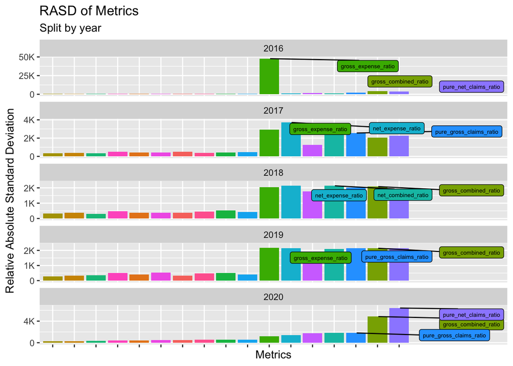

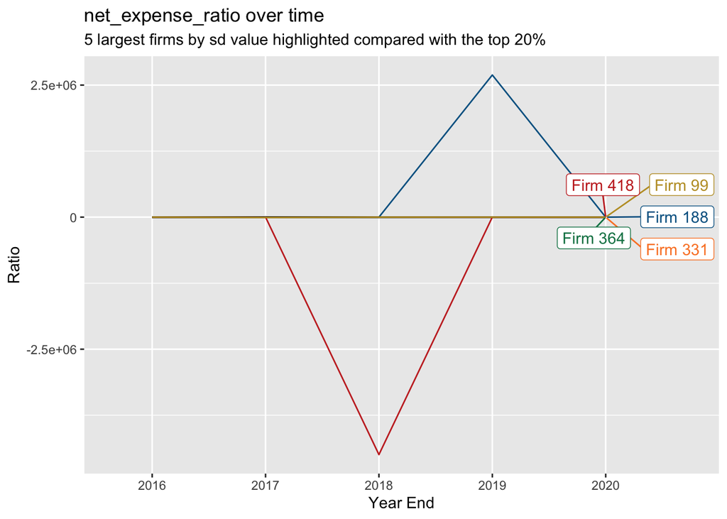

We can see from this graph that *net_expense_ratio* spikes has potentially come from these two enormous values that have been reported. I will add a filter to this chart and the other ratio charts to have median values between 0 and 0.87 (this is the range set by 3Q + 1.5 * IQR). I will be consistent in flagging and filtering outliers in this way.

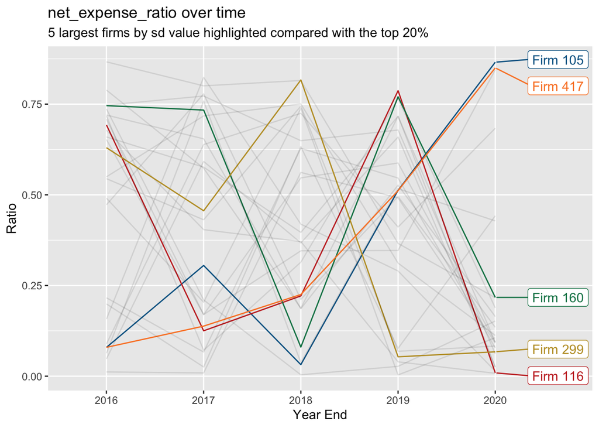

After filtering out misreporting firms, we can see the five firms whose data has changed most substantially over the period 2016-20. This is important for supervisors to be aware of because its ability to damage investors confidence in the firm as well as conduct any reasonable long-term financial planning.

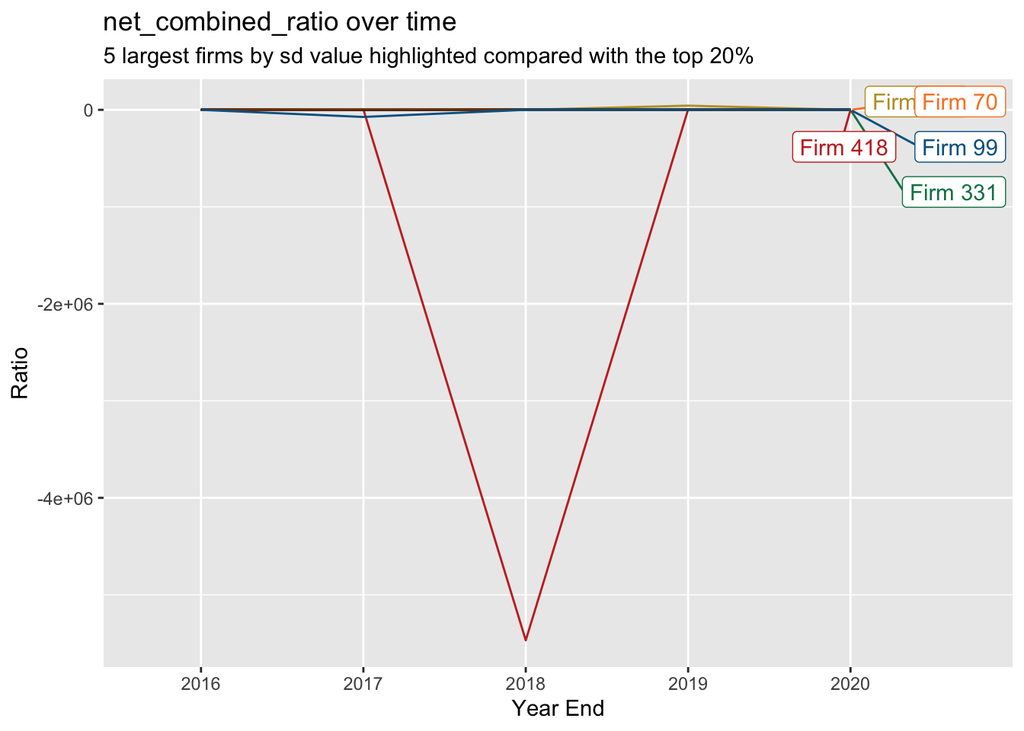

As Firm 418 has misreported both *net_combined_ratio* and *net_expense_ratio*, we can assume the issue is in a misreporting of their expenses which has had a knock-on impact on multiple of their larger KPIs.

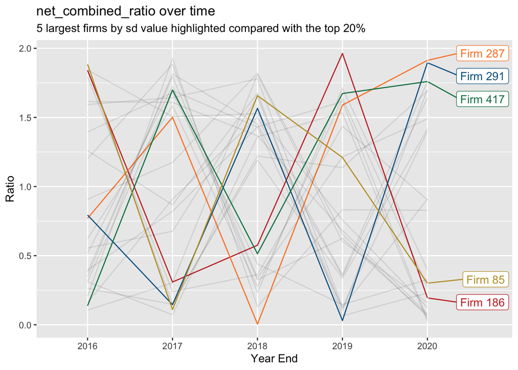

Again, once these are removed we can see that multiple firms with volatile ratios. Firms 287, 291 and 417 having both a volatile and high *net combined ratio* would be cause for concern for supervisors.

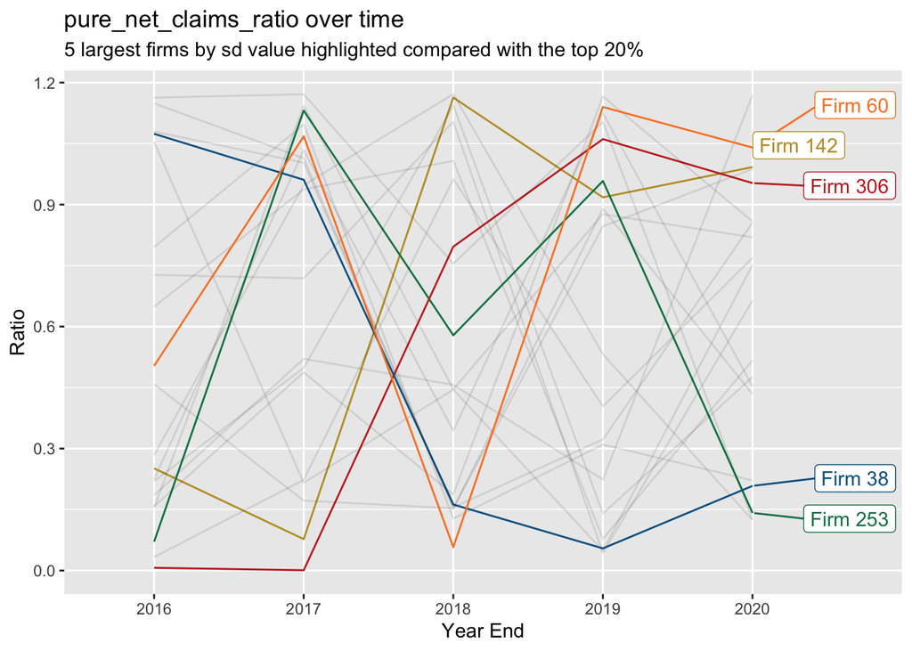

This is calculated as $\frac{Net Claims}{Net Earned Premium}$ and so a firm like 38 who has managed to reduce this from a poor position is a positive and something that would stop concern from supervisors.

## Outliers and Misreporting

I’ve shown a couple of techniques I have used to filter out outliers and highlight elements in the time series. I have chosen to use the interquartile range method due to the presence of extreme outliers in the data. Standard Deviation is influenced much more strongly by extreme outliers. I have created a flagging system, if the data point is outside of $(Q1 - 1.5 \times IQR, Q3 + 1.5 \times IQR,)$ for the entire metric population then it is a *‘IQR Outlier’*, if it is outside of the 1st or 9th quantile then it is labelled a *‘Decile Outlier’* else it has *‘No Flag’*.

| firm | eof_for_scr_m_outlier_flag | equity_m_outlier_flag | gwp_m_outlier_flag | gross_bel_m_outlier_flag | gross_claims_incurred_m_outlier_flag | gross_combined_ratio_outlier_flag | gross_expense_ratio_outlier_flag | nwp_m_outlier_flag | net_bel_m_outlier_flag | net_combined_ratio_outlier_flag | net_expense_ratio_outlier_flag | pure_gross_claims_ratio_outlier_flag | pure_net_claims_ratio_outlier_flag | scr_m_outlier_flag | scr_coverage_ratio_outlier_flag | total_assets_m_outlier_flag | total_liabilities_m_outlier_flag | year |
| --- | --- | --- | --- | --- | --- | --- | --- | --- | --- | --- | --- | --- | --- | --- | --- | --- | --- | --- |
| Firm 1 | IQR Outlier | IQR Outlier | IQR Outlier | No Flag | No Flag | No Flag | No Flag | IQR Outlier | No Flag | No Flag | No Flag | No Flag | No Flag | IQR Outlier | No Flag | IQR Outlier | IQR Outlier | 2016 |
| Firm 1 | No Flag | No Flag | No Flag | IQR Outlier | IQR Outlier | IQR Outlier | IQR Outlier | No Flag | IQR Outlier | IQR Outlier | IQR Outlier | IQR Outlier | IQR Outlier | No Flag | IQR Outlier | No Flag | No Flag | 2017 |
| Firm 1 | No Flag | No Flag | No Flag | No Flag | No Flag | No Flag | No Flag | No Flag | No Flag | No Flag | No Flag | No Flag | No Flag | No Flag | No Flag | No Flag | No Flag | 2018 |
| Firm 1 | No Flag | No Flag | No Flag | No Flag | No Flag | No Flag | No Flag | No Flag | No Flag | No Flag | No Flag | No Flag | No Flag | No Flag | No Flag | No Flag | No Flag | 2019 |
| Firm 1 | No Flag | No Flag | No Flag | No Flag | No Flag | No Flag | No Flag | No Flag | No Flag | No Flag | No Flag | No Flag | No Flag | No Flag | No Flag | No Flag | No Flag | 2020 |
| Firm 10 | Decile Outlier | No Flag | Decile Outlier | Decile Outlier | IQR Outlier | Decile Outlier | No Flag | No Flag | No Flag | No Flag | No Flag | No Flag | No Flag | No Flag | No Flag | IQR Outlier | No Flag | 2016 |
| Firm 10 | Decile Outlier | No Flag | No Flag | No Flag | No Flag | No Flag | Decile Outlier | No Flag | No Flag | No Flag | IQR Outlier | Decile Outlier | No Flag | Decile Outlier | No Flag | IQR Outlier | No Flag | 2017 |
| Firm 10 | No Flag | No Flag | No Flag | No Flag | No Flag | No Flag | Decile Outlier | Decile Outlier | No Flag | No Flag | No Flag | No Flag | Decile Outlier | No Flag | Decile Outlier | No Flag | No Flag | 2018 |
| Firm 10 | No Flag | Decile Outlier | Decile Outlier | No Flag | No Flag | No Flag | No Flag | No Flag | Decile Outlier | Decile Outlier | No Flag | Decile Outlier | No Flag | Decile Outlier | No Flag | No Flag | Decile Outlier | 2019 |
| Firm 10 | No Flag | Decile Outlier | No Flag | Decile Outlier | Decile Outlier | Decile Outlier | No Flag | Decile Outlier | Decile Outlier | Decile Outlier | Decile Outlier | No Flag | Decile Outlier | No Flag | Decile Outlier | No Flag | Decile Outlier | 2020 |

| firm | year | eof_for_scr_m |
| --- | --- | --- |
| Firm 12 | 2016 | 2.766183 |
| Firm 12 | 2016 | 2.460907 |
| Firm 12 | 2016 | 1.441494 |
| Firm 12 | 2016 | 2.460907 |
| Firm 12 | 2017 | 2.766183 |
| Firm 12 | 2017 | 2.460907 |
| Firm 12 | 2017 | 1.441494 |
| Firm 12 | 2017 | 2.186284 |
| Firm 12 | 2018 | 2.766183 |
| Firm 12 | 2018 | 2.460907 |
| Firm 12 | 2018 | 1.441494 |
| Firm 12 | 2018 | 2.575311 |
| Firm 12 | 2019 | 2.766183 |
| Firm 12 | 2019 | 2.460907 |
| Firm 12 | 2019 | 1.441494 |
| Firm 12 | 2019 | 1.398061 |
| Firm 12 | 2020 | 2.766183 |
| Firm 12 | 2020 | 2.460907 |
| Firm 12 | 2020 | 1.441494 |
| Firm 12 | 2020 | 5.210350 |

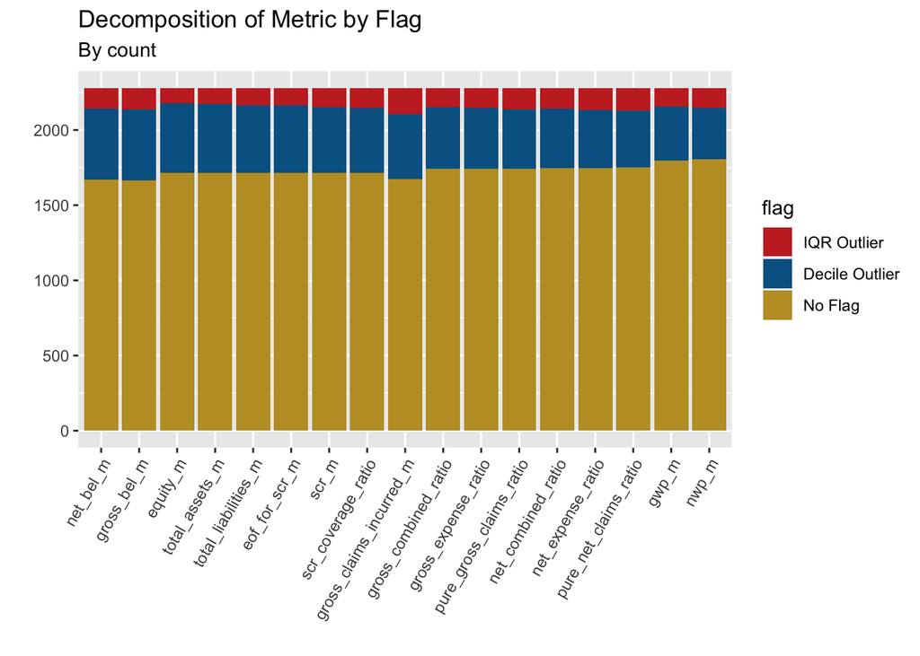